# The change in U.S stock market during past viral outbreaks

## By: Ha My Nguyen

### 1. Objectives

The objective of this report is to depict how U.S. equity markets recently have experienced turbulent trade due to deadly corona virus and also look back to compare with the past condition when the world have faced another storm of epidemic diseases. The report is based on the information that being scrapped from the website https://www.marketwatch.com/story/heres-how-the-stock-market-has-performed-during-past-viral-outbreaks-as-chinas-coronavirus-spreads-2020-01-22

Firstly, this report will explore the data by printing it to get the idea of how the data look like. Further exploration will be investigated by getting all the table tag. Next, data cleaning will be performed to clean unneccessary data and generate useful data into dataframe. Afterwards, this report will containn different types of chart to compare the change in US stock market by month, year and by disease phenomenon.

### 2. Data mining

```python
from bs4 import BeautifulSoup
```

```python
import requests
url = 'https://www.marketwatch.com/story/heres-how-the-stock-market-has-performed-during-past-viral-outbreaks-as-chinas-coronavirus-spreads-2020-01-22'
response = requests.get(url)
cnn = BeautifulSoup(response.text)
print(cnn.prettify())
```

[output not shown]

[output cut: 2813 more lines]

[output not shown]

```python
#get the table tag
table = cnn.select('#article-body table')[0]
table
```

```
<table> <tbody> <tr class="data"> <td align="left" colspan="" id="" valign="top"> <strong>Epidemic</strong> </td> <td align="left" colspan="" id="" valign="top"> <strong>Month end</strong> </td> <td align="left" colspan="" id="" valign="top"> <strong>6-month % change of S&amp;P</strong> </td> <td al…
```

Then, drop the uneccessary data and generate pandas dataframe

```python
import pandas as pd
data = table.findAll('tr')
print("Data is a {} and {} items long".format(type(data), len(data)))
data_without_header = data[1:-2]
headers = data[0]
col_headers = [th.getText().strip() for th in headers.findAll('td')]
df_data = [[td.getText() for td in tr.findAll('td')] for tr in data_without_header] # nested list-comp for 2d struct
df = pd.DataFrame(df_data, columns=col_headers)
df
```

```
Data is a <class 'bs4.element.ResultSet'> and 14 items long
```

|  | Epidemic | Month end | 6-month % change of S&P | 12-month % change of S&P |
| --- | --- | --- | --- | --- |
| 0 | HIV/AIDS | June 1981 | -0.3 | -16.5 |
| 1 | Pneumonic plague | September 1994 | 8.2 | 26.3 |
| 2 | SARS | April 2003 | 14.59 | 20.76 |
| 3 | Avian flu | June 2006 | 11.66 | 18.36 |
| 4 | Dengue Fever | September 2006 | 6.36 | 14.29 |
| 5 | Swine flu | April 2009 | 18.72 | 35.96 |
| 6 | Cholera | November 2010 | 13.95 | 5.63 |
| 7 | MERS | May 2013 | 10.74 | 17.96 |
| 8 | Ebola | March 2014 | 5.34 | 10.44 |
| 9 | Measles/Rubeola | December 2014 | 0.20 | -0.73 |
| 10 | Zika | January 2016 | 12.03 | 17.45 |

Next, convert the object type into float

```python
import matplotlib.pyplot as plt
df['6-month % change of S&P'] = df['6-month % change of S&P'].astype(float)
df['12-month % change of S&P'] = df['12-month % change of S&P'].astype(float)
df.dtypes
```

```
Epidemic                     object
Month end                    object
6-month % change of S&P     float64
12-month % change of S&P    float64
dtype: object
```

## 3. Plot

### 3.1 Bar chart

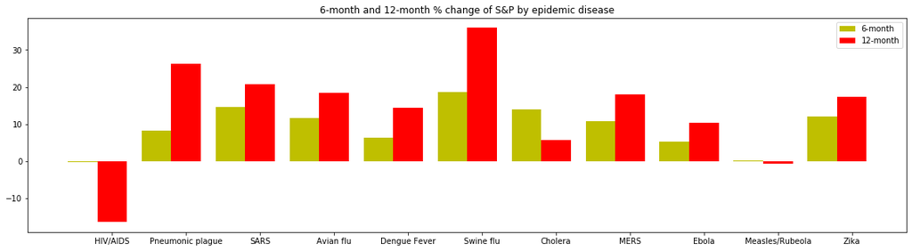

```python
plt.figure(figsize = (20,5))
x = list(range(len(df['Epidemic'])))
total_width, n = 0.8, 2
width = total_width / n
plt.bar(x, df['6-month % change of S&P'],width=width,label='6-month',fc = 'y')
for i in range(len(x)):
    x[i] = x[i] + width
plt.bar(x, df['12-month % change of S&P'],width=width,label='12-month',tick_label=df['Epidemic'],fc = 'r')
plt.title('6-month and 12-month % change of S&P by epidemic disease')
plt.legend()
```

According to the chart, Swine flu seems likely made highest influence in percentage change (raise up) of the US stock market during both timing period of 6-month and 12-month, however HIV/AIDS was showing negative growth.

### 3.2 Line chart

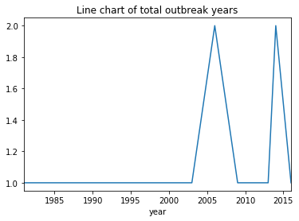

```python
dic = {'January': '1',
'February': '2',
'March': '3',
'April': '4',
'May': '5',
'June': '6',
'July': '7',
'August': '8',
'September': '9',
'October': '10',
'November': '11',
'December': '12'}
def func(x):
    month = dic[x.split(' ')[0]]
    year = x.split(' ')[1]
    return year + '-' + month
df['format-year-month'] = df['Month end'].apply(func)
df['format-year-month'] = pd.to_datetime(df['format-year-month'], format = '%Y-%m')
df['year'] = df['format-year-month'].dt.year
df['month'] = df['format-year-month'].dt.month
yearEpidemicGroup = df.groupby('year')['Epidemic'].count()
yearEpidemicGroup.plot()
plt.title('Line chart of total outbreak years')
```

### 3.3 Pie chart

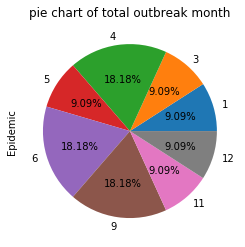

```python
monthEpidemicGroup = yearEpidemicGroup = df.groupby('month')['Epidemic'].count()
monthEpidemicGroup.plot(kind='pie', autopct='%.2f%%')
plt.title('pie chart of total outbreak month')
```

### 3.4 Scatter plot

```python
df
```

|  | Epidemic | Month end | 6-month % change of S&P | 12-month % change of S&P | format-year-month | year | month |
| --- | --- | --- | --- | --- | --- | --- | --- |
| 0 | HIV/AIDS | June 1981 | -0.30 | -16.50 | 1981-06-01 | 1981 | 6 |
| 1 | Pneumonic plague | September 1994 | 8.20 | 26.30 | 1994-09-01 | 1994 | 9 |
| 2 | SARS | April 2003 | 14.59 | 20.76 | 2003-04-01 | 2003 | 4 |
| 3 | Avian flu | June 2006 | 11.66 | 18.36 | 2006-06-01 | 2006 | 6 |
| 4 | Dengue Fever | September 2006 | 6.36 | 14.29 | 2006-09-01 | 2006 | 9 |
| 5 | Swine flu | April 2009 | 18.72 | 35.96 | 2009-04-01 | 2009 | 4 |
| 6 | Cholera | November 2010 | 13.95 | 5.63 | 2010-11-01 | 2010 | 11 |
| 7 | MERS | May 2013 | 10.74 | 17.96 | 2013-05-01 | 2013 | 5 |
| 8 | Ebola | March 2014 | 5.34 | 10.44 | 2014-03-01 | 2014 | 3 |
| 9 | Measles/Rubeola | December 2014 | 0.20 | -0.73 | 2014-12-01 | 2014 | 12 |
| 10 | Zika | January 2016 | 12.03 | 17.45 | 2016-01-01 | 2016 | 1 |

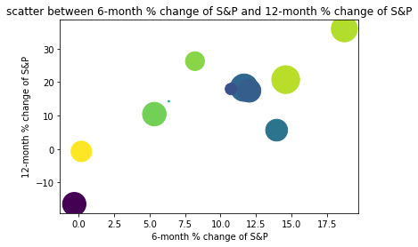

```python
import numpy as np
l = len(df['6-month % change of S&P'])
z = np.random.rand(l)
colors = np.random.rand(l)
plt.scatter(x=df['6-month % change of S&P'], y=df['12-month % change of S&P'], s=z*1000,c=colors)
plt.xlabel('6-month % change of S&P')
plt.ylabel('12-month % change of S&P')
plt.title('scatter between 6-month % change of S&P and 12-month % change of S&P')
```

It can be seen that the larger the value of 6-month% change of S & P, the larger the trend of 12-month% change of S & P.

## 4. Findings

This report has investigated serveral facts that:

- Swine flu seems likely made highest influence in percentage change (raise up) of the US stock market
- April, June, and September are likely become frequent months of virus outbreaks
- Back in 2002-2003, SARS has been recognize as dangerous epidemic, which esulted in a total of about 8,100 people being sickened during the 2003 outbreak, with 774 people dying. However, the S&P 500 posted a gain of 14.59% after the first occurrence.
- In the year 2006, the S&P 500 once again raised 11.66% in the roughly six months following reports for H5N1 pandemic.
- Indeed, the past epidemic and current corona virus caused potential discruptions and eonomic decline in China